# Data Management and Longitudinal Health Data Analysis

Natsumi Matsue

2026-10-27

## Project Overview

This portfolio demonstrates practical R programming skills in data management, quality assurance, and longitudinal health data analysis. Using an educational hypertension study data set, the project illustrates a reproducible analytical workflow, including data import, validation, duplicate detection, data integration, variable derivation, descriptive analysis, and visualization. The analysis focuses on changes in systolic blood pressure (SBP) across study visits and differences between intervention and usual care groups.

## Analytical Workflow

1. Data Import and Validation
2. Data Quality Assessment
3. Duplicate Detection and Data Integration
4. Longitudinal Data Transformation
5. Variable Derivation and Missing Data Handling
6. Descriptive Analysis and Data Visualization
7. Reproducibility and Quality Assurance Checks

```r
library(readr)
library(dplyr)
library(tidyr)
library(ggplot2)
library(here)
```

```r
# Check available data files
list.files(here::here("data"))
```

```
## [1] "edu_htn_adherence.csv" "edu_htn_analysis.csv"  "edu_htn_subjects.csv"
## [4] "edu_htn_visits.csv"
```

```r
# Verify that all required files exist
required_files <- c(
  "edu_htn_subjects.csv",
  "edu_htn_visits.csv",
  "edu_htn_analysis.csv",
  "edu_htn_adherence.csv"
)

stopifnot(
  all(file.exists(here::here("data", required_files)))
)

cat("All required data files found.\n")
```

```
## All required data files found.
```

## 1. Data Import and Validation

This section imports subject-level and visit-level data with explicitly defined variable types to ensure consistency and prevent data parsing errors.

```r
subjects <- read_csv(
  here("data", "edu_htn_subjects.csv"),
  col_types = cols(
    subject_id = col_character(),
    arm = col_character(),
    site = col_character(),
    age = col_double(),
    sex = col_character(),
    race = col_character(),
    bmi = col_double(),
    sbp_base = col_double(),
    randomized = col_character(),
    randomization_date = col_date(format = "%Y-%m-%d"),
    first_dose_date = col_date(format = "%Y-%m-%d"),
    .default = col_guess()
  )
)

visits <- read_csv(
  here("data", "edu_htn_visits.csv"),
  col_types = cols(
    subject_id = col_character(),
    visit_code = col_character(),
    visit_date = col_date(format = "%Y-%m-%d"),
    sbp = col_double(),
    week = col_double()
  )
)

# Verify successful imports
cat("Subjects:", nrow(subjects), "rows\n")
```

```
## Subjects: 240 rows
```

```r
cat("Visits:", nrow(visits), "rows\n")
```

```
## Visits: 960 rows
```

```r
# Check for parsing errors
stopifnot(
  nrow(problems(subjects)) == 0,
  nrow(problems(visits)) == 0
)

cat("Data imported successfully with no parsing errors.\n")
```

```
## Data imported successfully with no parsing errors.
```

## 2. Data Quality Assessment

This section evaluates missing data and checks the completeness of subject-level and visit-level datasets before data integration and analysis.

```r
# Summarize missing values in subject-level data
missing_subjects <- subjects |>
  summarise(across(everything(), ~ sum(is.na(.)))) |>
  pivot_longer(
    cols = everything(),
    names_to = "variable",
    values_to = "n_missing"
  ) |>
  arrange(desc(n_missing))

# Summarize missing values in visit-level data
missing_visits <- visits |>
  summarise(across(everything(), ~ sum(is.na(.)))) |>
  pivot_longer(
    cols = everything(),
    names_to = "variable",
    values_to = "n_missing"
  ) |>
  arrange(desc(n_missing))

# Display results
print(missing_subjects)
```

```
## # A tibble: 11 × 2
##    variable           n_missing
##    <chr>                  <int>
##  1 first_dose_date           15
##  2 subject_id                 0
##  3 arm                        0
##  4 site                       0
##  5 age                        0
##  6 sex                        0
##  7 race                       0
##  8 bmi                        0
##  9 sbp_base                   0
## 10 randomized                 0
## 11 randomization_date         0
```

```r
print(missing_visits)
```

```
## # A tibble: 5 × 2
##   variable   n_missing
##   <chr>          <int>
## 1 sbp               57
## 2 subject_id         0
## 3 visit_code         0
## 4 week               0
## 5 visit_date         0
```

### Duplicate Detection and Key Integrity

```r
# Check duplicate subject IDs
duplicate_subjects <- subjects |>
  count(subject_id) |>
  filter(n > 1)

# Check duplicate subject-visit combinations
duplicate_visits <- visits |>
  count(subject_id, visit_code) |>
  filter(n > 1)

# Identify visit records without a matching subject
orphan_visits <- anti_join(
  visits,
  subjects,
  by = "subject_id"
)

# Summarize quality checks
cat("Duplicate subject IDs:", nrow(duplicate_subjects), "\n")
```

```
## Duplicate subject IDs: 0
```

```r
cat("Duplicate subject-visit pairs:", nrow(duplicate_visits), "\n")
```

```
## Duplicate subject-visit pairs: 0
```

```r
cat("Orphan visit records:", nrow(orphan_visits), "\n")
```

```
## Orphan visit records: 0
```

```r
# Validate data integrity
stopifnot(
  nrow(duplicate_subjects) == 0,
  nrow(duplicate_visits) == 0,
  nrow(orphan_visits) == 0
)

cat("All key integrity checks passed.\n")
```

```
## All key integrity checks passed.
```

## 3. Data Integration

Subject-level demographic information is merged with visit-level blood pressure measurements using a many-to-one relationship. Key integrity and row counts are verified to prevent unintended duplication or loss of records.

```r
# Merge visit-level data with subject-level characteristics
visit_plus <- visits |>
  left_join(
    subjects |>
      select(subject_id, arm, age, sex, site),
    by = "subject_id",
    relationship = "many-to-one"
  )

# Verify that the join preserved all visit records
stopifnot(
  nrow(visit_plus) == nrow(visits),
  sum(is.na(visit_plus$arm)) == 0,
  sum(is.na(visit_plus$age)) == 0
)

# Display dimensions of merged dataset
cat("Merged dataset:", nrow(visit_plus), "rows,",
    ncol(visit_plus), "columns\n")
```

```
## Merged dataset: 960 rows, 9 columns
```

```r
cat("Data integration completed successfully.\n")
```

```
## Data integration completed successfully.
```

```r
# Preview merged dataset
head(visit_plus)
```

```
## # A tibble: 6 × 9
##   subject_id visit_code  week visit_date   sbp arm            age sex   site
##   <chr>      <chr>      <dbl> <date>     <dbl> <chr>        <dbl> <chr> <chr>
## 1 E001       BASELINE       0 2026-01-05  168. Usual care      66 Male  UCLA
## 2 E001       WEEK4          4 2026-02-01  164. Usual care      66 Male  UCLA
## 3 E001       WEEK8          8 2026-02-28  166. Usual care      66 Male  UCLA
## 4 E001       WEEK12        12 2026-03-28  173. Usual care      66 Male  UCLA
## 5 E002       BASELINE       0 2026-01-04  154. Intervention    66 Male  Harbor
## 6 E002       WEEK4          4 2026-02-05  148. Intervention    66 Male  Harbor
```

## 4. Longitudinal Data Transformation

Visit-level blood pressure measurements are reshaped from long to wide format to support participant-level longitudinal analysis. Each participant has one row, with separate columns for systolic blood pressure measurements at each study visit.

```r
# Reshape longitudinal SBP measurements into wide format
sbp_wide <- visits |>
  select(subject_id, visit_code, sbp) |>
  pivot_wider(
    names_from = visit_code,
    values_from = sbp,
    names_prefix = "sbp_"
  )

# Verify that each participant has one row
stopifnot(
  nrow(sbp_wide) == nrow(subjects),
  n_distinct(sbp_wide$subject_id) == nrow(sbp_wide)
)

# Display the reshaped dataset
cat("Wide dataset:", nrow(sbp_wide), "rows,",
    ncol(sbp_wide), "columns\n")
```

```
## Wide dataset: 240 rows, 5 columns
```

```r
head(sbp_wide)
```

```
## # A tibble: 6 × 5
##   subject_id sbp_BASELINE sbp_WEEK4 sbp_WEEK8 sbp_WEEK12
##   <chr>             <dbl>     <dbl>     <dbl>      <dbl>
## 1 E001               168.      164.      166.       173.
## 2 E002               154.      148.      142.       140.
## 3 E003               144.      146.      142.       146.
## 4 E004               135.      137       127.       132
## 5 E005               139.      150.      143.       134.
## 6 E006               151.      137.      137.       141.
```

## 5. Variable Derivation and Missing Data Handling

Changes in systolic blood pressure are calculated relative to the baseline visit. A participant is classified as a responder if their Week 12 SBP decreased by at least 10 mmHg. Missing outcome values are preserved rather than treated as non-response.

```r
# Derive changes from baseline at each follow-up visit
sbp_derived <- sbp_wide |>
  mutate(
    chg_wk4  = sbp_WEEK4  - sbp_BASELINE,
    chg_wk8  = sbp_WEEK8  - sbp_BASELINE,
    chg_wk12 = sbp_WEEK12 - sbp_BASELINE
  )

# Classify Week 12 responders
sbp_derived <- sbp_derived |>
  mutate(
    responder = case_when(
      is.na(chg_wk12) ~ NA,
      chg_wk12 <= -10 ~ TRUE,
      TRUE ~ FALSE
    )
  )

# Verify change calculations and missing value handling
stopifnot(
  sum(!is.na(sbp_derived$chg_wk12)) == 215,
  sum(is.na(sbp_derived$responder)) ==
    sum(is.na(sbp_derived$chg_wk12))
)

# Summarize derived variables
cat("Participants with observed Week 12 change:",
    sum(!is.na(sbp_derived$chg_wk12)), "\n")
```

```
## Participants with observed Week 12 change: 215
```

```r
cat("Participants with missing Week 12 change:",
    sum(is.na(sbp_derived$chg_wk12)), "\n")
```

```
## Participants with missing Week 12 change: 25
```

```r
cat("Week 12 responders:",
    sum(sbp_derived$responder, na.rm = TRUE), "\n")
```

```
## Week 12 responders: 47
```

```r
head(sbp_derived)
```

```
## # A tibble: 6 × 9
##   subject_id sbp_BASELINE sbp_WEEK4 sbp_WEEK8 sbp_WEEK12 chg_wk4 chg_wk8
##   <chr>             <dbl>     <dbl>     <dbl>      <dbl>   <dbl>   <dbl>
## 1 E001               168.      164.      166.       173.   -4.5    -2.60
## 2 E002               154.      148.      142.       140.   -6.10  -12
## 3 E003               144.      146.      142.       146.    2      -1.80
## 4 E004               135.      137       127.       132     1.90   -7.70
## 5 E005               139.      150.      143.       134.   11.1     3.90
## 6 E006               151.      137.      137.       141.  -14.3   -14.2
## # ℹ 2 more variables: chg_wk12 <dbl>, responder <lgl>
```

## 6. Descriptive Analysis and Data Visualization

Descriptive statistics are calculated to compare changes in systolic blood pressure and response rates between intervention and usual care groups. Participants with missing Week 12 outcomes are excluded from outcome-specific calculations but retained in the dataset.

```r
# Add treatment group information to derived dataset
analysis_data <- sbp_derived |>
  left_join(
    subjects |> select(subject_id, arm),
    by = "subject_id",
    relationship = "one-to-one"
  )

# Confirm all subjects are retained
stopifnot(
  nrow(analysis_data) == nrow(subjects),
  sum(is.na(analysis_data$arm)) == 0
)

# Summarize Week 12 outcomes by treatment group
arm_summary <- analysis_data |>
  group_by(arm) |>
  summarise(
    n_total = n(),
    n_observed = sum(!is.na(chg_wk12)),
    n_missing = sum(is.na(chg_wk12)),
    mean_change = round(mean(chg_wk12, na.rm = TRUE), 2),
    sd_change = round(sd(chg_wk12, na.rm = TRUE), 2),
    n_responders = sum(responder, na.rm = TRUE),
    responder_rate = round(
      100 * mean(responder, na.rm = TRUE), 1
    ),
    .groups = "drop"
  )

print(arm_summary)
```

```
## # A tibble: 2 × 8
##   arm          n_total n_observed n_missing mean_change sd_change n_responders
##   <chr>          <int>      <int>     <int>       <dbl>     <dbl>        <int>
## 1 Intervention     120        108        12       -8.21      6.64           39
## 2 Usual care       120        107        13       -2.31      5.65            8
## # ℹ 1 more variable: responder_rate <dbl>
```

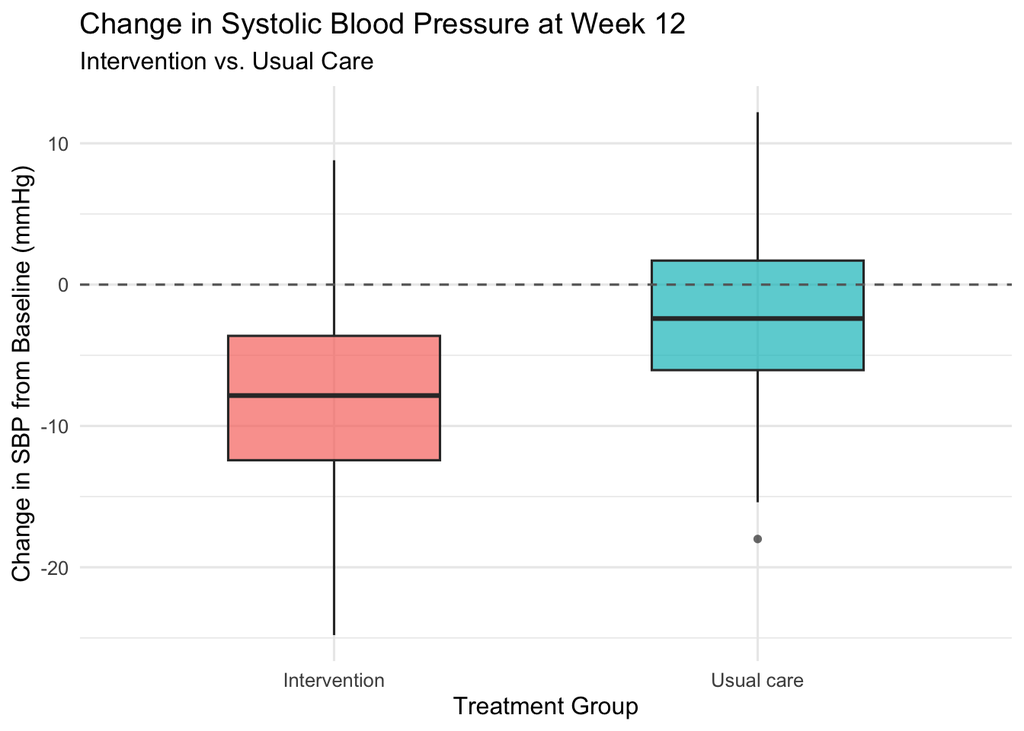

```r
# Visualize Week 12 SBP changes by treatment group
ggplot(
  analysis_data |> filter(!is.na(chg_wk12)),
  aes(x = arm, y = chg_wk12, fill = arm)
) +
  geom_boxplot(
    width = 0.5,
    alpha = 0.7,
    outlier.shape = 16
  ) +
  geom_hline(
    yintercept = 0,
    linetype = "dashed",
    color = "gray40"
  ) +
  labs(
    title = "Change in Systolic Blood Pressure at Week 12",
    subtitle = "Intervention vs. Usual Care",
    x = "Treatment Group",
    y = "Change in SBP from Baseline (mmHg)"
  ) +
  theme_minimal(base_size = 12) +
  theme(legend.position = "none")
```

### Results Interpretation

Among participants with observed Week 12 outcomes, the intervention group showed a greater mean reduction in systolic blood pressure (SBP) than the usual care group (-8.21 vs. -2.31 mmHg). The responder rate was also higher in the intervention group (36.1%) compared with the usual care group (7.5%). A responder was defined as a participant whose SBP decreased by at least 10 mmHg from baseline. The boxplot illustrates a downward shift in SBP changes among intervention participants relative to usual care participants. These findings are descriptive and do not establish statistical significance or causal effects. Participants with missing Week 12 outcomes were excluded from outcome-specific summaries, which may introduce bias if missingness is related to treatment response.

## 7. Reproducibility and Quality Assurance Checks

Final assertions verify the integrity of the analytical dataset, consistency of derived variables, and preservation of missing outcome values.

```r
# Verify the analytical dataset
stopifnot(
  nrow(analysis_data) == 240,
  n_distinct(analysis_data$subject_id) == 240,
  sum(is.na(analysis_data$chg_wk12)) == 25,
  sum(analysis_data$responder, na.rm = TRUE) == 47,
  sum(arm_summary$n_total) == 240,
  sum(arm_summary$n_observed) == 215,
  sum(arm_summary$n_missing) == 25
)

# Verify the responder classification
stopifnot(
  all(
    analysis_data$responder[!is.na(analysis_data$chg_wk12)] ==
      (analysis_data$chg_wk12[!is.na(analysis_data$chg_wk12)] <= -10)
  )
)

cat("All final quality assurance checks passed.\n")
```

```
## All final quality assurance checks passed.
```